# Intro to R, Part I

# A brief introduction to R packages

Packages are curated collections of functions and/or compiled code for use in R. Some commonly-downloaded, popular packages include sample data and documentation to explain and demonstrate implementation.  
Packages can be downloaded from the Comprehensive R Archive Network (CRAN), the primary repository for R packages. Each package submitted to CRAN is reviewed and tested thoroughly before release. Every package is released with a version number, and the most popular packages are frequently updated and released with a new version number.  
CRAN is a trusted source for up-to-date, consistent versions of R packages, and allows package accessibility across multiple servers in multiple regions called ‘mirrors’. Packages can also be downloaded through GitHub, but we’ll get to that later.

# 1. Using `install.packages()`

One of the most useful packages in R is `tidyverse`.  
Install `tidyverse` by typing `install.packages('tidyverse')` in the code chunk below.  
The `install.packages()` function is the easiest method to download packages from CRAN.  
View the documentation for `install.packages()` by clicking [**here.**](https://www.rdocumentation.org/packages/utils/versions/3.6.2/topics/install.packages)

```r
install.packages("tidyverse")
```

# 2. The `library()` function

Once the package is downloaded, the package must be called into virtual memory before it is used. In order to use the package, call it into virtual memory with the `library()` command.  
When downloading packages, the package name must be in quotation marks. When called into virtual memory with the `library()` command, no quotation marks are needed.

Put the `tidyverse` package into virtual memory by typing `library(tidyverse)` in the code chunk below.

```r
library(tidyverse)
```

# 3. Viewing package version with `packageVersion()`

In an R Markdown document, you can begin a new code chunk by adding three tick marks followed by a lower case r enclosed in curly brackets: `` ```{r} ``

You can close the code chunk with three tick marks: `` ``` ``.

Create a code chunk below and find the package version of tidyverse you’ve just downloaded by using the `packageVersion()` function.  
View the documentation for `packageVersion()` by clicking [**here.**](https://www.rdocumentation.org/packages/Biobase/versions/2.32.0/topics/package.version)

```r
packageVersion("tidyverse")
```

```
## [1] '2.0.0'
```

# 4. Importing a .csv file with `read.csv`

Read the .csv file titled `brfss2024tri.csv` into a dataframe with the `read.csv()` function. Name the resulting dataframe `brtri`.  
Hint: include the file path when reading the file, and remember to either double backslashes (`\`) or use forward slashes (`/`) in the file path.  
View the documentation for `read.csv()` by clicking [**here.**](https://www.rdocumentation.org/packages/COVID19/versions/2.0.3/topics/read.csv)

```r
brtri <- read.csv("brfss2024tri.csv")
```

# 5. The `colnames()` function

View the column names in the `brtri` dataframe with the `colnames()` function in the code chunk below.  
How many columns are in the dataframe?  
View the documentation for `colnames()` by clicking [**here.**](https://www.rdocumentation.org/packages/base/versions/3.6.2/topics/row+colnames)  
View additional methods for retrieving column names and details by clicking [**here.**](https://www.r-bloggers.com/2024/10/mastering-column-names-in-base-r-a-beginners-guide/)

```r
colnames(brtri)
```

```
##   [1] "X"        "STATE"    "FMONTH"   "IDATE"    "IMONTH"   "IDAY"
##   [7] "IYEAR"    "DISPCODE" "SEQNO"    "PSU"      "CTELENM1" "PVTRESD1"
##  [13] "COLGHOUS" "STATERE1" "CELPHON1" "LADULT1"  "NUMADULT" "RESPSLC1"
##  [19] "LANDSEX3" "SAFETIME" "CTELNUM1" "CELLFON5" "CADULT1"  "CELLSEX3"
##  [25] "PVTRESD3" "CCLGHOUS" "CSTATE1"  "LANDLINE" "HHADULT"  "SEXVAR"
##  [31] "GENHLTH"  "PHYSHLTH" "MENTHLTH" "POORHLTH" "PRIMINS2" "PERSDOC3"
##  [37] "MEDCOST1" "CHECKUP1" "EXERANY2" "LASTDEN4" "RMVTETH4" "CVDINFR4"
##  [43] "CVDCRHD4" "CVDSTRK3" "ASTHMA3"  "ASTHNOW"  "CHCSCNC1" "CHCOCNC1"
##  [49] "CHCCOPD3" "ADDEPEV3" "CHCKDNY2" "HAVARTH4" "DIABETE4" "DIABAGE4"
##  [55] "MARITAL"  "EDUCA"    "RENTHOM1" "NUMHHOL4" "NUMPHON4" "CPDEMO1C"
##  [61] "VETERAN3" "EMPLOY1"  "CHILDREN" "INCOME3"  "PREGNANT" "WEIGHT2"
##  [67] "HEIGHT3"  "DEAF"     "BLIND"    "DECIDE"   "DIFFWALK" "DIFFDRES"
##  [73] "DIFFALON" "HADMAM"   "HOWLONG"  "CERVSCRN" "CRVCLCNC" "CRVCLPAP"
##  [79] "CRVCLHPV" "HADHYST2" "HADSIGM4" "COLNSIGM" "COLNTES1" "SIGMTES1"
##  [85] "LASTSIG4" "COLNCNCR" "VIRCOLO1" "VCLNTES2" "SMALSTOL" "STOLTEST"
```

[output cut: 36 more lines]

# 6. Using `sapply()` to view column type

View the class of each column in the `brtri` dataframe by implementing the `sapply()` function with the `class()` function in the code chunk below.  
View the documentation for `sapply()` by clicking [**here.**](https://www.rdocumentation.org/packages/functools/versions/0.2.0/topics/Sapply)

```r
sapply(brtri, class)
```

```
##         X     STATE    FMONTH     IDATE    IMONTH      IDAY     IYEAR  DISPCODE
## "integer" "integer" "integer" "integer" "integer" "integer" "integer" "integer"
##     SEQNO       PSU  CTELENM1  PVTRESD1  COLGHOUS  STATERE1  CELPHON1   LADULT1
## "integer" "integer" "integer" "integer" "integer" "integer" "integer" "integer"
##  NUMADULT  RESPSLC1  LANDSEX3  SAFETIME  CTELNUM1  CELLFON5   CADULT1  CELLSEX3
## "integer" "integer" "integer" "integer" "integer" "integer" "integer" "integer"
##  PVTRESD3  CCLGHOUS   CSTATE1  LANDLINE   HHADULT    SEXVAR   GENHLTH  PHYSHLTH
## "integer" "integer" "integer" "integer" "integer" "integer" "integer" "integer"
##  MENTHLTH  POORHLTH  PRIMINS2  PERSDOC3  MEDCOST1  CHECKUP1  EXERANY2  LASTDEN4
## "integer" "integer" "integer" "integer" "integer" "integer" "integer" "integer"
##  RMVTETH4  CVDINFR4  CVDCRHD4  CVDSTRK3   ASTHMA3   ASTHNOW  CHCSCNC1  CHCOCNC1
## "integer" "integer" "integer" "integer" "integer" "integer" "integer" "integer"
##  CHCCOPD3  ADDEPEV3  CHCKDNY2  HAVARTH4  DIABETE4  DIABAGE4   MARITAL     EDUCA
## "integer" "integer" "integer" "integer" "integer" "integer" "integer" "integer"
##  RENTHOM1  NUMHHOL4  NUMPHON4  CPDEMO1C  VETERAN3   EMPLOY1  CHILDREN   INCOME3
## "integer" "integer" "integer" "integer" "integer" "integer" "integer" "integer"
##  PREGNANT   WEIGHT2   HEIGHT3      DEAF     BLIND    DECIDE  DIFFWALK  DIFFDRES
## "integer" "integer" "integer" "integer" "integer" "integer" "integer" "integer"
##  DIFFALON    HADMAM   HOWLONG  CERVSCRN  CRVCLCNC  CRVCLPAP  CRVCLHPV  HADHYST2
## "integer" "integer" "integer" "integer" "integer" "integer" "integer" "integer"
##  HADSIGM4  COLNSIGM  COLNTES1  SIGMTES1  LASTSIG4  COLNCNCR  VIRCOLO1  VCLNTES2
## "integer" "integer" "integer" "integer" "integer" "integer" "integer" "integer"
##  SMALSTOL  STOLTEST  STOOLDN2  BLDSTFIT  SDNATES1  SMOKE100  SMOKDAY2   USENOW3
## "integer" "integer" "integer" "integer" "integer" "integer" "integer" "integer"
##  ECIGNOW3  LCSFIRST  LCSNUMCG  LCSCTSC1  LCSSCNCR  LCSCTWHN   ALCDAY4  AVEDRNK4
## "integer" "integer" "integer" "integer" "integer" "integer" "integer" "integer"
##  DRNK3GE5  MAXDRNKS  FLUSHOT7  FLSHTMY3  IMFVPLA5  PNEUVAC4   HIVTST7  HIVTSTD3
## "integer" "integer" "integer" "integer" "integer" "integer" "integer" "integer"
##  HIVRISK5  PDIABTS1  PREDIAB2  DIABTYPE  INSULIN1  CHKHEMO3  EYEEXAM1  DIABEYE1
## "integer" "integer" "integer" "integer" "integer" "integer" "integer" "integer"
##  DIABEDU1  FEETSORE  ARTHEXER  SHINGLE2  HPVADVC4  HPVADSH1  TETANUS1  CNCRDIFF
## "integer" "integer" "integer" "logical" "logical" "logical" "logical" "integer"
##   CNCRAGE  CNCRTYP2  CSRVTRT3  CSRVDOC1   CSRVSUM  CSRVRTRN  CSRVINST  CSRVINSR
## "integer" "integer" "integer" "integer" "integer" "integer" "integer" "integer"
##  CSRVDEIN  CSRVCLIN  CSRVPAIN  CSRVCTL2  PSATEST1  PSATIME1  PCPSARS2  PSASUGS1
## "integer" "integer" "integer" "integer" "integer" "integer" "integer" "integer"
##  PCSTALK2  CIMEMLO1   CDWORRY  CDDISCU1   CDHOUS1  CDSOCIA1  CAREGIV1  CRGVREL5
## "integer" "logical" "logical" "logical" "logical" "logical" "integer" "integer"
##  CRGVPRB4  CRGVALZD  CRGVNURS  CRGVPER2  CRGVHOU2  CRGVHRS2  CRGVLNG2  ACEDEPRS
## "integer" "integer" "integer" "integer" "integer" "integer" "integer" "logical"
```

[output cut: 21 more lines]

```
## "integer" "integer" "integer" "integer" "integer" "integer" "integer" "integer"
##   RACEGR3   RACEPRV       SEX   AGEG5YR   AGE65YR     AGE80      AGEG     HTIN4
## "integer" "integer" "integer" "integer" "integer" "integer" "integer" "integer"
##      HTM4     WTKG3      BMI5   BMI5CAT    RFBMI5   CHLDCNT    EDUCAG   INCOMG1
## "integer" "integer" "integer" "integer" "integer" "integer" "integer" "integer"
##   RFMAM23   MAM402Y   CRVSCRN   RFPAP37   HPV5YR1   PAPHPV1   HADCOLN   CLNSCP2
## "integer" "integer" "integer" "integer" "integer" "integer" "integer" "integer"
##   HADSIGM   SGMSCP2   SGMS102   RFBLDS6   STOLDN2   VIRCOL2   SBONTI2   CRCREC3
## "integer" "integer" "integer" "integer" "integer" "integer" "integer" "integer"
##   SMOKER3   RFSMOK3   CURECI3   LCSLAST   LCSNUMC    LCSAGE   LCSYSMK   PACKDAY
## "integer" "integer" "integer" "integer" "integer" "integer" "integer" "integer"
##   PACKYRS   LCSYQTS   LCSSMKG   LCSELIG   LCSCTSN   LCSPSTF  DRNKANY6   DROCDY4
## "integer" "integer" "integer" "integer" "integer" "integer" "integer" "integer"
##   RFBING6   DRNKWK3   RFDRHV9   FLSHOT7   PNEUMO3   AIDTST4
## "integer" "integer" "integer" "integer" "integer" "integer"
```

# 7. The `table()` function

Use the `table()` function to view the frequencies of the `STATE` column in the `brtri` dataframe in the code chunk below. Use the parameter `useNA` to view the number of rows with missing data.  
View the documentation for `table()` by clicking [**here.**](https://www.rdocumentation.org/packages/base/versions/3.6.2/topics/table)

```r
table(brtri[, "STATE"], useNA = "ifany")
```

```
##
##     9    34    36
##  7213  8666 43913
```

# 8. Viewing the number of rows with `nrow()`

Use the `nrow()` function to view the number of rows in the `brtri` dataframe in the code chunk below.  
View the documentation for `nrow()` by clicking [**here.**](https://www.rdocumentation.org/packages/base/versions/3.6.2/topics/nrow)

```r
nrow(brtri)
```

```
## [1] 59792
```

# 9. The BRFSS Codebook: Height

The Behavioral Risk Factor Surveillance Survey (BRFSS) data in the `brtri` dataframe have a codebook with the following information:

Label: Reported Height in Feet and Inches  
Section Name: Demographics

Type of Variable: Num  
Variable Name: HEIGHT3

Question: About how tall are you without shoes? (If respondent answers in metrics, put a 9 in the first column)[Round fractions down.]

| Value | Value Label | Frequency | Percentage | Weighted Percentage |
| --- | --- | --- | --- | --- |
| 200-711 | Height (ft/inches) |  |  |  |
|  | Notes: 0 _ / _ _ = feet / inches | 425,837 | 95.85 | 94.10 |
| 7777 | Don’t know/Not sure | 4,198 | 0.94 | 1.49 |
| 9061-9998 | Height (meters/centimeters) |  |  |  |
|  | Notes: The initial ‘9’ indicates |  |  |  |
|  | this was a metric value. | 7,793 | 1.75 | 2.91 |
| 9999 | Refused | 6,442 | 1.45 | 1.50 |
| BLANK | Not asked or Missing | 13,400 |  |  |

Use the `table()` function to get a frequency table of the data in the `HEIGHT3` column in the code chunk below.  
Given the information in the table above, what range of values would you say are in feet and inches in column `HEIGHT3`?  
What range of values would you say are in centimeters?  
View the documentation for `table()` by clicking [**here.**](https://www.rdocumentation.org/packages/base/versions/3.6.2/topics/table)

```r
table(brtri$HEIGHT3, useNA = "ifany")
```

```
##
##  300  305  307  309  311  400  401  402  403  404  405  406  407  408  409  410
##    6    4    1    1    1   22    3    7    3    3   36   15   21   58  118  210
##  411  500  501  502  503  504  505  506  507  508  509  510  511  600  601  602
##  603 1931 1961 3659 3681 4611 4349 4841 4553 4103 3773 4189 3213 3497 1661 1410
##  603  604  605  606  607  608  609  610  611  700  701  702  704  705  706  708
##  861  495  180   79   41   27   11   12    9    5    2    2    4    3    1    1
##  711 7777 9090 9092 9095 9096 9098 9100 9102 9103 9104 9105 9106 9107 9108 9110
##    3  668    4    1    1    1    1    2    1    2    2   13    5    2    1    4
## 9111 9115 9118 9123 9125 9127 9129 9130 9132 9133 9135 9136 9137 9138 9140 9141
##    1    5    1    1    1    1    1    9    1    1    4    2    2    3   21    2
## 9142 9143 9144 9145 9146 9147 9148 9149 9150 9151 9152 9153 9154 9155 9156 9157
##    3    3    5   33    4    5   15   14  111   14   59   43   36   96   49   37
## 9158 9159 9160 9161 9162 9163 9164 9165 9166 9167 9168 9169 9170 9171 9172 9173
##   48   21  169   12   48   41   29  119   19   38   53   38  129   22   34   32
## 9174 9175 9176 9177 9178 9179 9180 9181 9182 9183 9184 9185 9186 9187 9188 9190
##   18   85   23   14   25    9   45    2   11   11    8   15    5    3    2    4
## 9191 9192 9193 9195 9196 9198 9200 9207 9251 9252 9999 <NA>
##    2    3    1    1    1    1    1    1    1    1  995 2081
```

# 10. Extracting height: feet, inches

According to the information in the BRFSS codebook, values from 200 to 711 in the `HEIGHT3` column represent height in feet and inches.  
For example, the value ‘511’ actually represents a height of 5 feet and 11 inches.  
The codebook also explains that values beginning with the number ‘9’ in the `HEIGHT3` column precede digits that represent height recorded in centimeters.  
The number ‘9’ only signifies that the remaining digits are recorded in centimeters and should not be included in the measurement values.  
In order to compare height of each respondent, we will need to convert all height values to inches or centimeters.

We will accomplish this step by step: 1. Where height is recorded in feet and inches, for example ‘511’, we’11 separate values of feet and values of inches into separate `HEIGHTft` and `HEIGHTin` columns. 2. Where height is measured in centimeters, for example ‘9170’, we will need to extract the last three digits–the values following the leading’9’–and store as values of centimeters in a separate `HEIGHTcm` column. 3. After we have three new columns (`HEIGHTft`, `HEIGHTin`, `HEIGHTcm`), we can convert values conditionally by row until each respondent has height recorded in inches and centimeters.

Extract the ‘foot’ (the first digit) and ‘inch’ (the last two digits) components of each respondent’s height from the `HEIGHT3` column conditionally–only if `brtri$HEIGHT3>=200 & brtri$HEIGHT3<=711`.  
Use conditional methods with logical indexing and the `substr()` function to create `brtri$HEIGHTft` and `brtri$HEIGHTin` columns and populate with the correct digits from the `HEIGHT3` column.  
When subsetting columns, `NA` values are not allowed, so remember to include `!is.na(brtri$HEIGHT3)` in the logical indexing.

You can use Stack Overflow as a resource on conditional methods with logical indexing by clicking [**here.**](https://stackoverflow.com/questions/13871614/replacing-values-from-a-column-using-a-condition-in-r)  
View the documentation for `substr()` by clicking [**here.**](https://www.rdocumentation.org/packages/base/versions/3.6.2/topics/substr)

```r
brtri$HEIGHTft[brtri$HEIGHT3 >= 200 & brtri$HEIGHT3 <=
    711 & !is.na(brtri$HEIGHT3)] <- as.numeric(substr(as.character(brtri$HEIGHT3[brtri$HEIGHT3 >=
    200 & brtri$HEIGHT3 <= 711 & !is.na(brtri$HEIGHT3)]),
    1, 1))
brtri$HEIGHTin[brtri$HEIGHT3 >= 200 & brtri$HEIGHT3 <=
    711 & !is.na(brtri$HEIGHT3)] <- as.numeric(substr(as.character(brtri$HEIGHT3[brtri$HEIGHT3 >=
    200 & brtri$HEIGHT3 <= 711 & !is.na(brtri$HEIGHT3)]),
    2, 3))
```

# 11. Transforming height: total inches

Create a new column called `HEIGHTtotin` and populate it with values in total inches using column operations and the new `HEIGHTft` and `HEIGHTin` columns we just created.  
You should be able to create the column and populated it with values in a single line of code.

```r
brtri$HEIGHTtotin <- (brtri$HEIGHTft * 12) + brtri$HEIGHTin
```

# 12. Extracting height: centimeters

Create a new column called `HEIGHTcm` and populate it with `NA` values.  
Extract the height of each respondent recorded in centimeters from the `HEIGHT3` column conditionally–only if `brtri$HEIGHT3>=9061 & brtri$HEIGHT3<=9998`.  
Use conditional methods with logical indexing and the `substr()` function to populate with the correct digits from the `HEIGHT3` column.  
Remember that the last three digits of the `HEIGHT3` column represent respondent height in centimeters if the leading digit is a ‘9’.  
When subsetting columns, `NA` values are not allowed, so remember to include `!is.na(brtri$HEIGHT3)` in the logical indexing.

```r
brtri$HEIGHTcm <- NA
brtri$HEIGHTcm[brtri$HEIGHT3 >= 9061 & brtri$HEIGHT3 <=
    9998 & !is.na(brtri$HEIGHT3)] <- as.numeric(substr(as.character(brtri$HEIGHT3[brtri$HEIGHT3 >=
    9061 & brtri$HEIGHT3 <= 9998 & !is.na(brtri$HEIGHT3)]),
    2, 4))
```

# 13. Transforming height: total centimeters

Create a new column called `HEIGHTtotcm` by simply copying the column `brtri$HEIGHTcm`.  
This new column `HEIGHTtotcm` will hold the height of each respondent in centimeters.  
For rows with height recorded in inches, we will convert from inches to centimeters and populate `HEIGHTtotcm` with converted values.

Use the `round()` function to round to the nearest whole centimeter.

View the documentation for `round()` by clicking [**here.**](https://www.rdocumentation.org/packages/base/versions/3.6.2/topics/Round)

```r
brtri$HEIGHTtotcm <- brtri$HEIGHTcm
brtri$HEIGHTtotcm[is.na(brtri$HEIGHTcm) & !is.na(brtri$HEIGHTtotin)] <- round(brtri$HEIGHTtotin[is.na(brtri$HEIGHTcm) &
    !is.na(brtri$HEIGHTtotin)] * 2.54, 0)
```

# 14. Transforming height: total meters

Create a new column called `HEIGHTtotm` by simply converting the column `brtri$HEIGHTtotcm` to meters.  
Use the `round()` function to round values to four decimal places.

```r
brtri$HEIGHTtotm <- round(brtri$HEIGHTtotcm/100, 4)
```

# 15. Transforming height: total centimeters to total inches

Create a new column called `HEIGHTtotin` by simply converting the column `brtri$HEIGHTtotcm` to inches.  
Use the `round()` function to round values to the nearest whole inch.

```r
brtri$HEIGHTtotin[!is.na(brtri$HEIGHTtotcm) & is.na(brtri$HEIGHTtotin)] <- round(brtri$HEIGHTtotcm[!is.na(brtri$HEIGHTtotcm) &
    is.na(brtri$HEIGHTtotin)] * 0.393701, 0)
```

# 16. Respondent Sex: Creating a factor

The Behavioral Risk Factor Surveillance Survey (BRFSS) data in the `brtri` dataframe have a codebook with the following information:

Label: Sex of Respondent  
Section Name: Respondent Sex

Type of Variable: Num  
Variable Name: SEXVAR

Question: Sex of Respondent

| Value | Value Label | Frequency | Percentage | Weighted Percentage |
| --- | --- | --- | --- | --- |
| 1 | Male: Code=1 if LANDSEX3=1 or CELLSEX3=1 | 217,487 | 47.52 | 49.12 |
| 2 | Female: Code=2 if LANDSEX3=2 or CELLSEX3=2 | 240,183 | 52.48 | 50.88 |

Create a new variable `SEX` and populate it with empty values (““).  
Use conditional logic and indexing to code the value of `SEX` for all rows where `SEXVAR==1` as ‘Male’.  
Use conditional logic and indexing to code the value of `SEX` for all rows where `SEXVAR==2` as ‘Female’.  
Use the `factor()` function to convert `brtri$SEX` to a factor.

View the documentation for `factor()` by clicking [**here.**](https://www.rdocumentation.org/packages/base/versions/3.6.2/topics/factor)

```r
brtri$SEX <- ""
brtri$SEX[brtri$SEXVAR == 1] <- "Male"
brtri$SEX[brtri$SEXVAR == 2] <- "Female"
brtri$SEX <- factor(brtri$SEX, level = c("Male", "Female"))
```

# 17. Plotting an histogram of (unweighted) height stratified by sex

Use the code chunk below to plot a histogram of respondent height in meters stratified by sex using `ggplot` and `geom_histogram`.  
Use the resources in the hyperlinks below.  
In particular, view the code in the R code gallery.

View the documentation for `ggplot()` by clicking [**here.**](https://www.rdocumentation.org/packages/ggplot2/versions/0.9.0/topics/ggplot)  
View the documentation for `geom_histogram()` by clicking [**here.**](https://www.rdocumentation.org/packages/ggplot2/versions/0.9.1/topics/geom_histogram)  
View a gallery of R code and histograms with several groups by clicking [**here.**](https://r-graph-gallery.com/histogram_several_group.html)

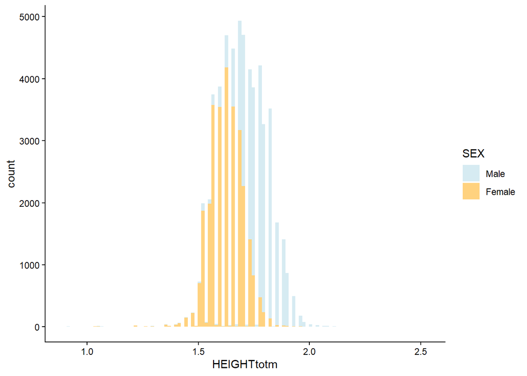

```r
nbins <- length(unique(brtri$HEIGHTtotm))

brtri %>%
    ggplot(aes(HEIGHTtotm, fill = SEX)) + geom_histogram(aes(fill = SEX),
    bins = nbins, alpha = 0.5) + scale_fill_manual(values = c("lightblue",
    "orange"), aesthetics = "fill", breaks = waiver(),
    na.value = "grey50") + theme_classic() + theme(legend.position = "right")
```

# 18. Compare our calculated `HEIGHTtotin` column values to BRFSS height column values in inches

Use the `head()` function to view the first rows of the `HEIGHTtotin` and `HTIN4` columns in the `brtri` dataframe.

View the documentation for `head()` by clicking [**here.**](https://www.rdocumentation.org/packages/utils/versions/3.6.2/topics/head)

```r
head(brtri[, c("HEIGHTtotin", "HTIN4")])
```

```
##   HEIGHTtotin HTIN4
## 1          64    64
## 2          NA    NA
## 3          67    67
## 4          67    67
## 5          64    64
## 6          60    60
```

# 19. Compare our calculated `HEIGHTtotm` column values to BRFSS height column values in meters

Use the `head()` function to view the first rows of the `HEIGHTtotm` and `HTM4` columns in the `brtri` dataframe.

```r
head(brtri[, c("HEIGHTtotm", "HTM4")])
```

```
##   HEIGHTtotm HTM4
## 1       1.63  163
## 2         NA   NA
## 3       1.70  170
## 4       1.70  170
## 5       1.63  163
## 6       1.52  152
```

# 20. The BRFSS Codebook: Weight

The Behavioral Risk Factor Surveillance Survey (BRFSS) data in the `brtri` dataframe have a codebook with the following information:

Label: Reported Weight in Pounds  
Section Name: Demographics

Type of Variable: Num  
Variable Name: WEIGHT2

Question: About how much do you weigh without shoes? (If respondent answers in metrics, put a 9 in the first column)[Round fractions up.]

| Value | Value Label | Frequency | Percentage | Weighted Percentage |
| --- | --- | --- | --- | --- |
| 50-0776 | Weight (pounds) |  |  |  |
|  | Notes: 0 _ _ _ = weight in pounds | 417,106 | 93.66 | 93.36 |
| 7777 | Don’t know/Not sure | 7,740 | 1.74 | 2.11 |
| 9023-9352 | Weight (kilograms) |  |  |  |
|  | Notes: The initial ‘9’ indicates |  |  |  |
|  | this was a metric value. | 4,190 | 0.94 | 1.36 |
| 9999 | Refused | 16,301 | 3.66 | 3.17 |
| BLANK | Not asked or Missing | 12,333 |  |  |

Use the `table()` function to get a frequency table of the data in the `WEIGHT2` column in the code chunk below.  
Given the information in the table above, what range of values would you say are in pounds in column `WEIGHT2`?  
What range of values within the column `WEIGHT2` are recorded in kilograms?

```r
table(brtri$WEIGHT2, useNA = "ifany")
```

```
##
##   50   56   58   59   60   61   62   65   67   68   70   71   72   74   75   76
##    1    1    1    1    3    1    1    3    4    1    3    1    3    3    3    1
##   77   78   80   81   82   83   84   85   86   87   88   89   90   91   92   93
##    2    4   13    1    2    1    3   12    5    3    4    7   44    2   11    7
##   94   95   96   97   98   99  100  101  102  103  104  105  106  107  108  109
##    9   44   19   20   32   20  207   14   39   36   37  193   40   61   75   31
##  110  111  112  113  114  115  116  117  118  119  120  121  122  123  124  125
##  394   26  120   70   77  398   88   86  147   64  902   55  123  130   82  763
##  126  127  128  129  130  131  132  133  134  135  136  137  138  139  140  141
##  114  161  182  102 1358   49  185  119  116 1135  139  147  253   94 1791   55
##  142  143  144  145  146  147  148  149  150  151  152  153  154  155  156  157
##  193  181  125 1153  124  186  247  107 2361   80  217  164  187 1079  161  170
##  158  159  160  161  162  163  164  165  166  167  168  169  170  171  172  173
##  262   92 2338   68  259  169  153 1524   87  155  302  114 2260   62  275  153
```

[output cut: 44 more lines]

# 21. Extracting weight: pounds

Create a new column called `WEIGHTlb` and populate it with `NA` values.  
Extract the weight of each respondent recorded in pounds from the `WEIGHT2` column conditionally–only if `brtri$WEIGHT2>=50 & brtri$WEIGHT2<=776`.  
Use conditional methods with logical indexing and the `substr()` function to populate with the correct digits from the `WEIGHT2` column.  
Remember that the last three digits of the `WEIGHT2` column represent respondent weight in kilograms if the leading digit is a ‘9’.  
Convert values to pounds where necessary.

When subsetting columns, `NA` values are not allowed, so remember to include `!is.na(brtri$WEIGHT2)` in the logical indexing.

```r
brtri$WEIGHTlb <- NA
brtri$WEIGHTlb[brtri$WEIGHT2 >= 50 & brtri$WEIGHT2 <=
    776 & !is.na(brtri$WEIGHT2)] <- brtri$WEIGHT2[brtri$WEIGHT2 >=
    50 & brtri$WEIGHT2 <= 776 & !is.na(brtri$WEIGHT2)]
brtri$WEIGHTlb[brtri$WEIGHT2 >= 9023 & brtri$WEIGHT2 <=
    9352 & !is.na(brtri$WEIGHT2)] <- as.numeric(substr(as.character(brtri$WEIGHT2[brtri$WEIGHT2 >=
    9023 & brtri$WEIGHT2 <= 9352 & !is.na(brtri$WEIGHT2)]),
    2, 4)) * 2.20462
```

# 22. Extracting weight: kilograms

When subsetting columns, `NA` values are not allowed, so remember to include `!is.na(brtri$WEIGHT2)` in the logical indexing.

```r
brtri$WEIGHTkg <- NA
brtri$WEIGHTkg[brtri$WEIGHT2 >= 9023 & brtri$WEIGHT2 <=
    9352 & !is.na(brtri$WEIGHT2)] <- as.numeric(substr(as.character(brtri$WEIGHT2[brtri$WEIGHT2 >=
    9023 & brtri$WEIGHT2 <= 9352 & !is.na(brtri$WEIGHT2)]),
    2, 4))
brtri$WEIGHTkg[brtri$WEIGHT2 >= 50 & brtri$WEIGHT2 <=
    776 & !is.na(brtri$WEIGHT2)] <- round(brtri$WEIGHT2[brtri$WEIGHT2 >=
    50 & brtri$WEIGHT2 <= 776 & !is.na(brtri$WEIGHT2)] *
    0.453592, 2)
```

# 23. Compare our calculated `WEIGHTkg` column values to BRFSS weight column values

The Behavioral Risk Factor Surveillance Survey (BRFSS) data in the `brtri` dataframe have a codebook with the following information:

Label: Computed Weight in Kilograms  
Section Name: Calculated Variables

Type of Variable: Num  
Variable Name: WTKG3

Question: Reported weight in kilograms

| Value | Value Label | Frequency | Percentage | Weighted Percentage |
| --- | --- | --- | --- | --- |
| 2300-29500 | Weight in kilograms |  |  |  |
|  | [2 implied decimal places] |  |  |  |
|  | Notes: 0001 <= WEIGHT2 <= 650 |  |  |  |
|  | or 9023 <= WEIGHT2 <= 9295 |  |  |  |
|  | (non-metric WEIGHT2 value divided |  |  |  |
|  | by 2.2046) | 421,278 | 100.00 | 100.00 |
| BLANK | Don’t know/Refused/Not asked or Missing |  |  |  |
|  | Notes: WEIGHT2 = 7777 or 9999 |  |  |  |
|  | or not in accepted values |  |  |  |
|  | or WEIGHT2 = Missing | 36,392 |  |  |

Use the `head()` function to view the first rows of the `WEIGHTlb`, `WEIGHTkg`, and `WTKG3` columns in the `brtri` dataframe.  
Based on what you see, how do the values of the column `WEIGHTkg` compare to the column `WTKG3`?

```r
head(brtri[, c("WEIGHTlb", "WEIGHTkg", "WTKG3")])
```

```
##   WEIGHTlb WEIGHTkg WTKG3
## 1      205    92.99  9299
## 2       NA       NA    NA
## 3      175    79.38  7938
## 4      230   104.33 10433
## 5      240   108.86 10886
## 6      132    59.87  5987
```

# 24. Calculate BMI for each respondent from `WEIGHTkg` and `HEIGHTtotm`

From respondent weight in kilograms and height in meters, create a new column `BMIall` by calculating BMI in kilograms per meters squared.

```r
brtri$BMIall <- brtri$WEIGHTkg/(brtri$HEIGHTtotm)^2
```

# 25. Compare our calculated `BMIall` column values to BRFSS BMI column values

The Behavioral Risk Factor Surveillance Survey (BRFSS) data in the `brtri` dataframe have a codebook with the following information:

Label: Computed body mass index  
Section Name: Calculated Variables

Type of Variable: Num  
Variable Name: BMI5

Question: Body Mass Index (BMI)

| Value | Value Label | Frequency | Percentage | Weighted Percentage |
| --- | --- | --- | --- | --- |
| 1-9999 | 1 or greater |  |  |  |
|  | Notes: WTKG3/(HTM4*HTM4) |  |  |  |
|  | (Has 2 implied decimal places) | 414,633 | 100.00 | 100.00 |
| BLANK | Don’t know/Refused/Missing |  |  |  |
|  | Notes: WTKG3 = 777 or 999 or HTM4 = 777 or 999 |  |  |  |

Use the `head()` function to view the first rows of the `BMIall` and `BMI5` columns in the `brtri` dataframe.  
Based on what you see, how do the values of the column `BMIall` compare to the column `BMI5`?

```r
head(brtri[, c("BMIall", "BMI5")])
```

```
##     BMIall BMI5
## 1 34.99944 3519
## 2       NA   NA
## 3 27.46713 2741
## 4 36.10035 3602
## 5 40.97256 4120
## 6 25.91326 2578
```